# Homework 3

STAT 334

Krishnanshu Gupta, Ishaan Sathaye, Sreshta Talluri

2024-04-27

# Problem 2

## Part (a)

```r
#Import the Data
Hitters = read_excel("Hitters.xls")
str(Hitters)
```

```
## tibble [322 × 21] (S3: tbl_df/tbl/data.frame)
##  $ Name     : chr [1:322] "Andy Allanson" "Alan Ashby" "Alvin Davis" "Andre Dawson" ...
##  $ AtBat    : num [1:322] 293 315 479 496 321 594 185 298 323 401 ...
##  $ Hits     : num [1:322] 66 81 130 141 87 169 37 73 81 92 ...
##  $ HmRun    : num [1:322] 1 7 18 20 10 4 1 0 6 17 ...
##  $ Runs     : num [1:322] 30 24 66 65 39 74 23 24 26 49 ...
##  $ RBI      : num [1:322] 29 38 72 78 42 51 8 24 32 66 ...
##  $ Walks    : num [1:322] 14 39 76 37 30 35 21 7 8 65 ...
##  $ Years    : num [1:322] 1 14 3 11 2 11 2 3 2 13 ...
##  $ CAtBat   : num [1:322] 293 3449 1624 5628 396 ...
##  $ CHits    : num [1:322] 66 835 457 1575 101 ...
##  $ CHmRun   : num [1:322] 1 69 63 225 12 19 1 0 6 253 ...
##  $ CRuns    : num [1:322] 30 321 224 828 48 501 30 41 32 784 ...
##  $ CRBI     : num [1:322] 29 414 266 838 46 336 9 37 34 890 ...
##  $ CWalks   : num [1:322] 14 375 263 354 33 194 24 12 8 866 ...
##  $ League   : chr [1:322] "A" "N" "A" "N" ...
##  $ Division : chr [1:322] "E" "W" "W" "E" ...
##  $ PutOuts  : num [1:322] 446 632 880 200 805 282 76 121 143 0 ...
##  $ Assists  : num [1:322] 33 43 82 11 40 421 127 283 290 0 ...
##  $ Errors   : num [1:322] 20 10 14 3 4 25 7 9 19 0 ...
##  $ Salary   : num [1:322] NA 475 480 500 91.5 750 70 100 75 1100 ...
##  $ NewLeague: chr [1:322] "A" "N" "A" "N" ...
```

```r
Hitters=data.frame(Hitters[,-1], row.names = Hitters$Name)
head(Hitters)
```

```
##                  AtBat Hits HmRun Runs RBI Walks Years CAtBat CHits CHmRun
## Andy Allanson      293   66     1   30  29    14     1    293    66      1
## Alan Ashby         315   81     7   24  38    39    14   3449   835     69
## Alvin Davis        479  130    18   66  72    76     3   1624   457     63
## Andre Dawson       496  141    20   65  78    37    11   5628  1575    225
## Andres Galarraga   321   87    10   39  42    30     2    396   101     12
## Alfredo Griffin    594  169     4   74  51    35    11   4408  1133     19
##                  CRuns CRBI CWalks League Division PutOuts Assists Errors
## Andy Allanson       30   29     14      A        E     446      33     20
## Alan Ashby         321  414    375      N        W     632      43     10
## Alvin Davis        224  266    263      A        W     880      82     14
## Andre Dawson       828  838    354      N        E     200      11      3
## Andres Galarraga    48   46     33      N        E     805      40      4
## Alfredo Griffin    501  336    194      A        W     282     421     25
##                  Salary NewLeague
## Andy Allanson        NA         A
## Alan Ashby        475.0         N
## Alvin Davis       480.0         A
## Andre Dawson      500.0         N
## Andres Galarraga   91.5         N
## Alfredo Griffin   750.0         A
```

## Part (b)

### (i)

```r
Hitters['Barry Bonds', ]
```

```
##             AtBat Hits HmRun Runs RBI Walks Years CAtBat CHits CHmRun CRuns
## Barry Bonds   413   92    16   72  48    65     1    413    92     16    72
##             CRBI CWalks League Division PutOuts Assists Errors Salary NewLeague
## Barry Bonds   48     65      N        E     280       9      5    100         N
```

### (ii)

```r
Hitters['Ken Griffey', ]
```

```
##             AtBat Hits HmRun Runs RBI Walks Years CAtBat CHits CHmRun CRuns
## Ken Griffey   490  150    21   69  58    35    14   6126  1839    121   983
##             CRBI CWalks League Division PutOuts Assists Errors Salary NewLeague
## Ken Griffey  707    600      A        E      96       5      3   1000         N
```

```r
ken_salary = Hitters['Ken Griffey', 'Salary']
barry_salary = Hitters['Barry Bonds', 'Salary']

paste("Ken Griffey's salary is:", ken_salary, ", and Barry Bonds' salary is:", barry_salary)
```

```
## [1] "Ken Griffey's salary is: 1000 , and Barry Bonds' salary is: 100"
```

Based on the output, Ken Griffey has a larger salary than Barry Bonds.

## Part (c)

```r
Hitters_minusWalks = Hitters[, -6]
head(Hitters_minusWalks)
```

```
##                  AtBat Hits HmRun Runs RBI Years CAtBat CHits CHmRun CRuns CRBI
## Andy Allanson      293   66     1   30  29     1    293    66      1    30   29
## Alan Ashby         315   81     7   24  38    14   3449   835     69   321  414
## Alvin Davis        479  130    18   66  72     3   1624   457     63   224  266
## Andre Dawson       496  141    20   65  78    11   5628  1575    225   828  838
## Andres Galarraga   321   87    10   39  42     2    396   101     12    48   46
## Alfredo Griffin    594  169     4   74  51    11   4408  1133     19   501  336
##                  CWalks League Division PutOuts Assists Errors Salary NewLeague
## Andy Allanson        14      A        E     446      33     20     NA         A
## Alan Ashby          375      N        W     632      43     10  475.0         N
## Alvin Davis         263      A        W     880      82     14  480.0         A
## Andre Dawson        354      N        E     200      11      3  500.0         N
## Andres Galarraga     33      N        E     805      40      4   91.5         N
## Alfredo Griffin     194      A        W     282     421     25  750.0         A
```

## Part (d)

### (i)

Andy Allanson’s salary is NA.

### (ii)

```r
which(is.na(Hitters), arr.ind=TRUE)
```

```
##                  row col
## Andy Allanson      1  19
## Billy Beane       16  19
## Bruce Bochte      19  19
## Bob Boone         23  19
## Bobby Grich       31  19
## Bob Horner        33  19
## Bobby Meacham     37  19
## Ben Oglivie       39  19
## Bip Roberts       40  19
## Bill Russell      42  19
## Billy Sample      43  19
## Butch Wynegar     45  19
## Cecil Cooper      49  19
## Cliff Johnson     53  19
## Charlie Moore     58  19
## Doug Baker        65  19
## Dann Bilardello   67  19
## Dave Collins      70  19
## Darren Daulton    72  19
## Danny Heep        78  19
## Dave Kingman      81  19
## Darryl Motley     84  19
## Dickie Thon       95  19
## Enos Cabell       98  19
## Ernest Riles     102  19
## Ernie Whitt      104  19
## Fred Lynn        105  19
## Floyd Rayford    106  19
## Franklin Stubbs  107  19
## George Foster    115  19
## Gorman Thomas    126  19
## Juan Bonilla     139  19
## Julio Cruz       145  19
## Jerry Hairston   151  19
## Joe Orsulak      158  19
## Jorge Orta       159  19
## Jamie Quirk      161  19
## Jeff Stone       170  19
## Jim Traber       172  19
## Jerry Willard    174  19
## Luis Rivera      198  19
## Lonnie Smith     200  19
## Mike Brown       204  19
## Mike Fitzgerald  209  19
## Mickey Hatcher   211  19
## Nick Esasky      226  19
## Omar Moreno      229  19
## -Pete O'Brien    236  19
## Rich Gedman      247  19
## Ricky Jones      251  19
## Randy Kutcher    254  19
## Rudy Law         255  19
## Reggie Williams  271  19
## Tony Armas       284  19
## Toby Harrah      293  19
## -Tom O'Malley    299  19
## Tony Perez       303  19
## Tim Raines       306  19
## Wayne Krenchicki 317  19
```

```r
sum(is.na(Hitters$Salary))
```

```
## [1] 59
```

There are 59 salaries missing.

### (iii)

```r
Hitters.NoNA = na.omit(Hitters)
sum(is.na(Hitters.NoNA$Salary))
```

```
## [1] 0
```

Now there are 0 missing (NA) values in the salaries column, so the na.omit() function was able to omit/remove the rows with missing salaries.

## Part (e)

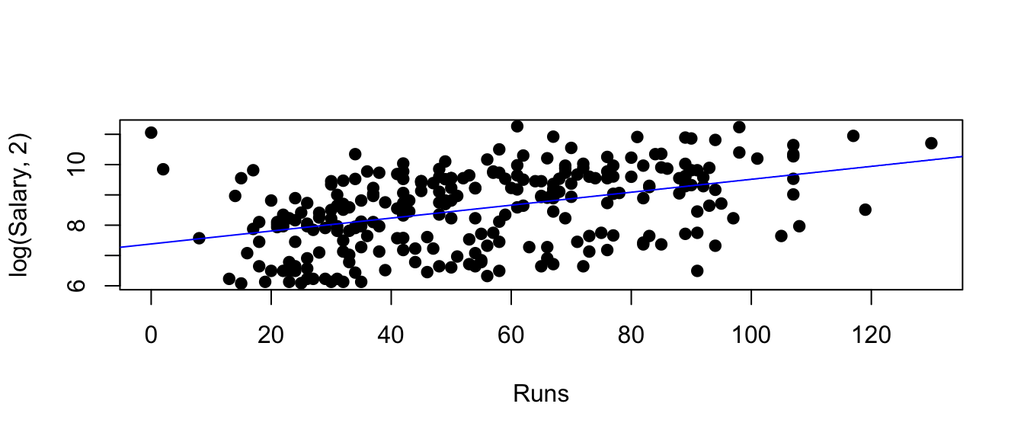

```r
plot(log(Salary,2)~Runs, data=Hitters.NoNA, pch=19)
salary.fit=lm(log(Salary,2)~Runs, data=Hitters.NoNA)
abline(salary.fit, col='blue')
```

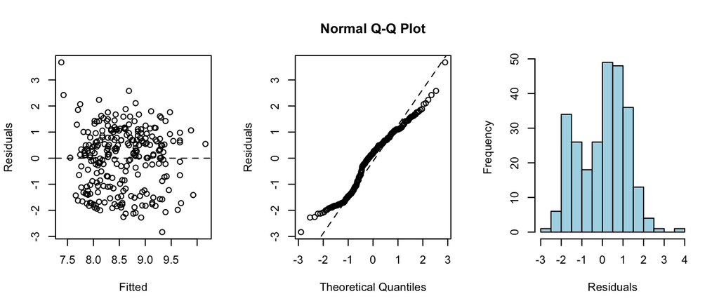

```r
par(mfrow=c(1,3))  #plot in 1x3 grid
plot(resid(salary.fit)~fitted(salary.fit), ylab='Residuals', xlab='Fitted')
abline(h=0, lty=2)
qqnorm(resid(salary.fit), ylab='Residuals');
qqline(resid(salary.fit), lty=2)
hist(resid(salary.fit), main='', col='lightblue', xlab='Residuals')
```

```r
par(mfrow=c(1,1))
```

## Part (f)

### (i)

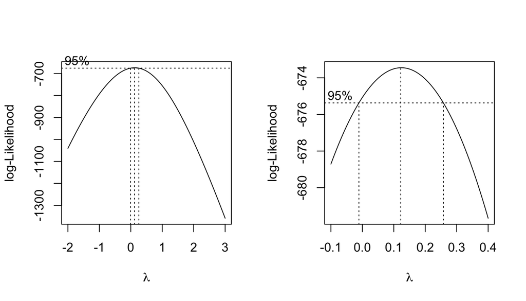

```r
library(MASS)
par(mfrow=c(1,2))
boxcox(Salary~Runs, data=Hitters.NoNA, plotit=TRUE, lambda=seq(-2,3,length=100))
boxcox(Salary~Runs, data=Hitters.NoNA, plotit=TRUE, lambda=seq(-.1,.4,length=100))
```

```r
par(mfrow=c(1,1))
```

### (ii)

To create a one-by-four plot grid, we’d use the command ‘par(mfrow=c(1,4))’, which creates the intended layout of 1 row and 4 columns.

## Part (g)

### (i)

```r
confint(salary.fit, level=0.95)
```

```
##                  2.5 %     97.5 %
## (Intercept) 7.04632374 7.71542915
## Runs        0.01583719 0.02691709
```

### (ii)

To get the 90% confidence interval, we’d use the command: ‘confint(salary.fit, level=0.90)’, where we just change the level to 0.90 compared to part I.

# Problem 3

```r
stopping <- read.table("./stopping.txt", header=TRUE, sep="\t")
head(stopping)
```

```
##   dist speed
## 1    4     4
## 2    2     5
## 3    8     5
## 4    8     5
## 5    4     5
## 6    6     7
```

## Part (a)

```r
par(mfrow=c(2,2))
plot(dist~speed,data=stopping,pch=19)
stopping.fit0=lm(dist~speed,data=stopping)
abline(stopping.fit0,col='blue')
summary(stopping.fit0)
```

```
##
## Call:
## lm(formula = dist ~ speed, data = stopping)
##
## Residuals:
##     Min      1Q  Median      3Q     Max
## -25.141  -7.300  -2.141   6.044  35.946
##
## Coefficients:
##             Estimate Std. Error t value Pr(>|t|)
## (Intercept) -20.2734     3.2384   -6.26 4.25e-08 ***
## speed         3.1366     0.1517   20.68  < 2e-16 ***
## ---
## Signif. codes:  0 '***' 0.001 '**' 0.01 '*' 0.05 '.' 0.1 ' ' 1
##
## Residual standard error: 11.8 on 61 degrees of freedom
## Multiple R-squared:  0.8752, Adjusted R-squared:  0.8731
## F-statistic: 427.7 on 1 and 61 DF,  p-value: < 2.2e-16
```

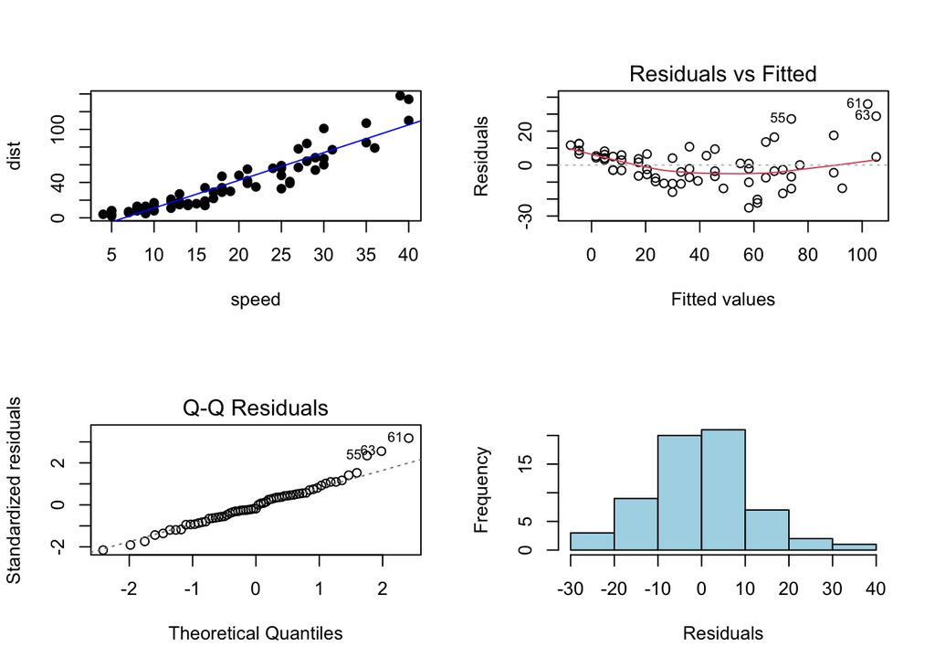

```r
plot(stopping.fit0,c(1,2))
hist(resid(stopping.fit0),main="", xlab="Residuals",col='lightblue')
```

```r
par(mfrow=c(1,1))
```

1. Linearity is slightly violated as there is a slight trend/curve in the residuals vs. fitted graph. There seems to be unequal variances in the data. Normality seems fine (however, few points in the qq plot which are not on the line).
2. Our analysis suggests changing the power in the response variable by decreasing the power. We are thinking a square root or log transformation might help for this particular data.

## Part (b)

First Transformation: sqrt(y)

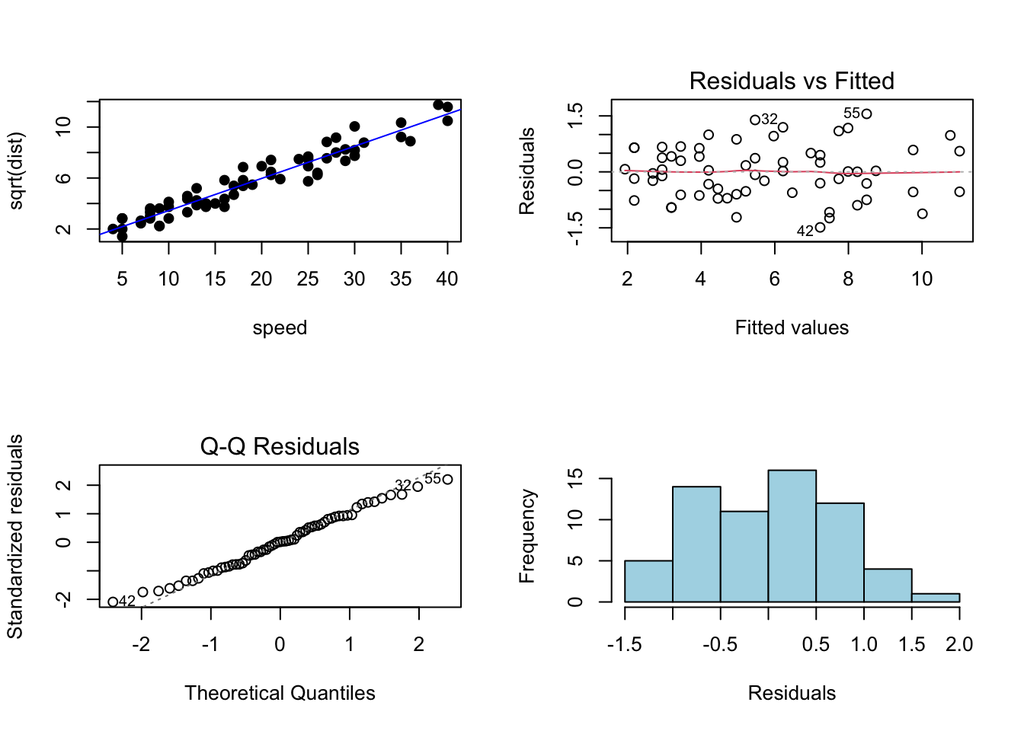

```r
par(mfrow=c(2,2))
plot(sqrt(dist)~speed,data=stopping, pch=19, ylab='sqrt(dist)')

stopping.fit1=lm(sqrt(dist)~speed,data=stopping)
abline(stopping.fit1,col='blue')
plot(stopping.fit1,c(1,2))

hist(resid(stopping.fit1),main="", xlab="Residuals",col='lightblue')
```

```r
par(mfrow=c(1,1))
```

This model already seems much better. Linearity is not-violated. There appears to be an equal variance. Normality is good, but not the best. So, we can try another transformation.

Second Transformation: log(y)

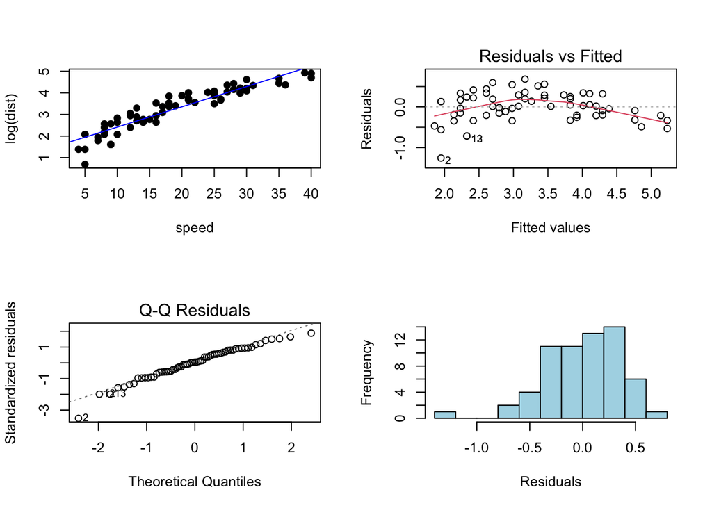

```r
par(mfrow=c(2,2))
plot(log(dist)~speed,data=stopping, pch=19, ylab='log(dist)')

stopping.fit2=lm(log(dist)~speed,data=stopping)
abline(stopping.fit2,col='blue')
plot(stopping.fit2,c(1,2))

hist(resid(stopping.fit2), main="", xlab="Residuals",col='lightblue')
```

```r
par(mfrow=c(1,1))
```

This model seems much worse. Linearity is violated. There seems to be unequal variance in the residual analysis. Normality also seems to be violated.

From the residual analysis’, the sqrt transformation for the response variable (y) seems to be the better model for this data. As we decrease the power for the y variable, the models seem to be getting worse.

We should also test to see if transforming the x variable results in a better model.

Third Transformation: sqrt(x)

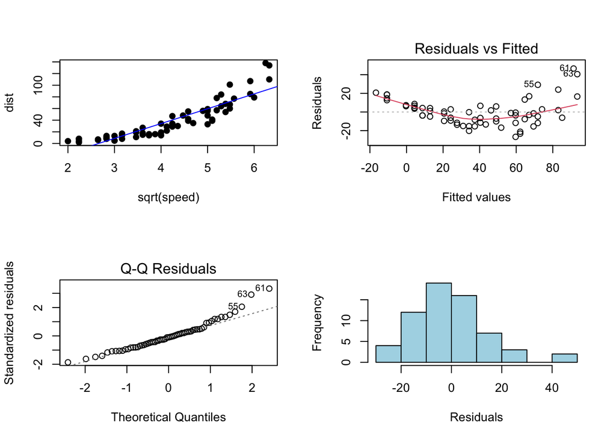

```r
par(mfrow=c(2,2))
plot(dist~sqrt(speed),data=stopping, pch=19, xlab='sqrt(speed)')

stopping.fit3=lm(dist~sqrt(speed),data=stopping)
abline(stopping.fit3,col='blue')
plot(stopping.fit3,c(1,2))

hist(resid(stopping.fit3),main="", xlab="Residuals",col='lightblue')
```

```r
par(mfrow=c(1,1))
```

This model also seems to be worse than the first transformation one. Linearity is violated. There is unequal variance in the residual analysis. Normality also is violated (from the histogram).

**Conclusion:** The best transformation seems to be a sqrt transformation in just the y (response) variable.

## Part (c)

According to this [source](https://www.physicsclassroom.com/mmedia/energy/cs.cfm), the equation between speed and stopping distance is 0.5 * m * v^2 = F * d. This means that dist is proportional to speed/velocity squared meaning that speed is proportional to sqrt(distance). This is the same model that we found to be best in part b.

## Part (d)

### (i)

Box-Cox Transformation

```r
library(car)
powerTransform(dist~speed,data=stopping)
```

```
## Estimated transformation parameter
##        Y1
## 0.4146443
```

The Box-Cox procedure recommends a power of 0.4146 for the transformation.

### (ii)

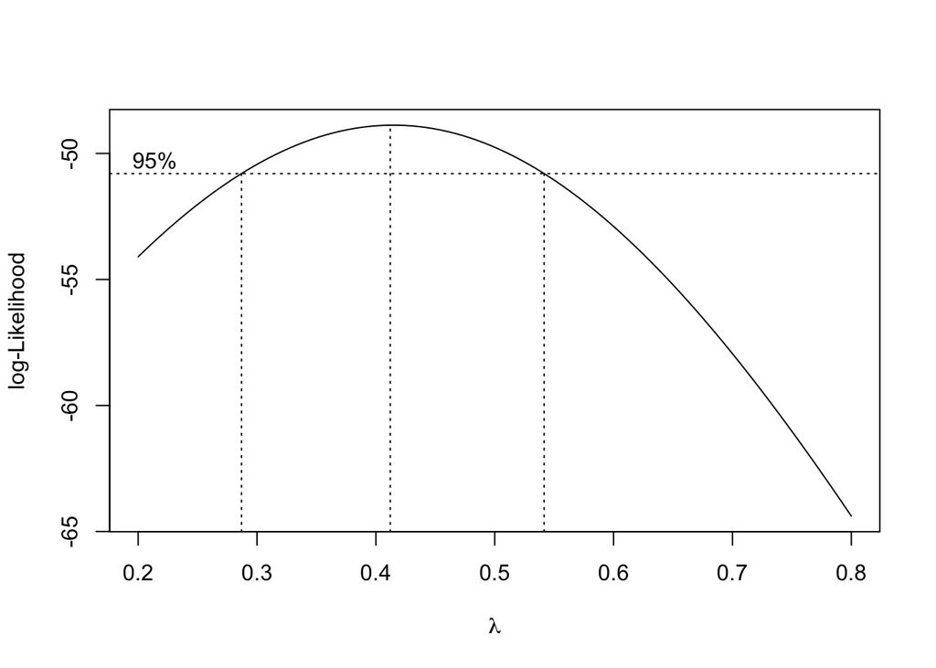

```r
library(MASS)
boxcox(dist~speed,data=stopping,lambda = seq(0.2, 0.8, by = 0.01))
```

The Box-Cox procedure produces an interval of around 0.29 to 0.54 which fits with our sqrt model (as sqrt is power of 0.5).

## Part (e)

### (i)

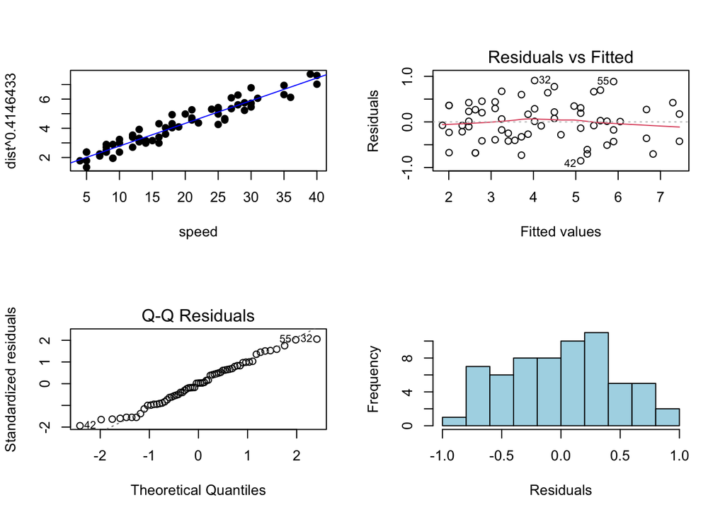

```r
par(mfrow=c(2,2))
plot(I(dist^0.4146443)~speed,data=stopping, pch=19, ylab='dist^0.4146433')

stopping.boxcox=lm(I(dist^0.4146443) ~ speed, data = stopping)
abline(stopping.boxcox,col='blue')
plot(stopping.boxcox,c(1,2))

hist(resid(stopping.boxcox),main="", xlab="Residuals",col='lightblue')
```

```r
par(mfrow=c(1,1))
```

For this model and based on these plots, linearity is not violated, variance appears to be equal, and normality seems to not be violated.

### (ii)

```r
shapiro.test(resid(stopping.boxcox))
```

```
##
##  Shapiro-Wilk normality test
##
## data:  resid(stopping.boxcox)
## W = 0.97989, p-value = 0.3909
```

Since the p-value is 0.3909 which is greater than the significance level of 0.05, we fail to reject the null hypothesis and therefore do not have sufficient evidence to conclude that the data deviates from a normal distribution (at out given significance levels).

```r
library(lmtest)
bptest(stopping.boxcox)
```

```
##
##  studentized Breusch-Pagan test
##
## data:  stopping.boxcox
## BP = 0.8977, df = 1, p-value = 0.3434
```

Since the p-value is 0.3434 which is greater than the significance value of 0.05, we fail to reject the null hypothesis and therefore do not have sufficient evidence to conclude that the variance varies across our regression model.

# Problem 4

## Part (a)

```r
sweetnessData = read.table('sweetness.txt', header=TRUE, sep="\t")
```

### (i)

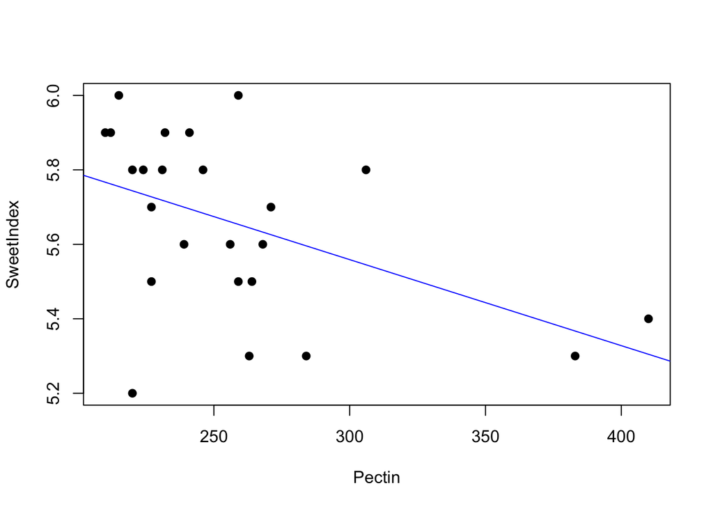

```r
plot(SweetIndex~Pectin,data=sweetnessData,pch=19)
sweet.fit=lm(SweetIndex~Pectin,data=sweetnessData)
abline(sweet.fit,col='blue')
```

### (ii)

```r
summary(sweet.fit)
```

```
##
## Call:
## lm(formula = SweetIndex ~ Pectin, data = sweetnessData)
##
## Residuals:
##      Min       1Q   Median       3Q      Max
## -0.54373 -0.11039  0.06089  0.13432  0.34638
##
## Coefficients:
##               Estimate Std. Error t value Pr(>|t|)
## (Intercept)  6.2520679  0.2366220  26.422   <2e-16 ***
## Pectin      -0.0023106  0.0009049  -2.554   0.0181 *
## ---
## Signif. codes:  0 '***' 0.001 '**' 0.01 '*' 0.05 '.' 0.1 ' ' 1
##
## Residual standard error: 0.215 on 22 degrees of freedom
## Multiple R-squared:  0.2286, Adjusted R-squared:  0.1936
## F-statistic:  6.52 on 1 and 22 DF,  p-value: 0.01811
```

Equation for the least squares line is y = 6.252 - 0.002x, where x is the pectin in parts per million and y is the sweet index.

## Part (b)

#### Hypotheses:

$H_0: \beta_1 = 0$ (no relationship between the sweetness and the amount of pectin)

$H_a: \beta_1 < 0$ (significant negative linear relationship between sweetness and amount of pectin)

This test is one-sided because we are only interested in the negative relationship between sweetness and pectin.

#### Test Statistic

```r
summary(sweet.fit)$coefficients
```

```
##                 Estimate   Std. Error   t value     Pr(>|t|)
## (Intercept)  6.252067909 0.2366219512 26.422181 3.690479e-18
## Pectin      -0.002310626 0.0009048803 -2.553515 1.811236e-02
```

The test statistic is -2.554.

#### Degrees of Freedom

The degrees of freedom is 22.

#### P-Value

```r
summary(sweet.fit)$coefficients[2,4]
```

```
## [1] 0.01811236
```

#### Conclusion

Since the p-value is less than 0.05, we reject the null hypothesis that there is no relationship between sweetness index and the amount of pectin. There is sufficient evidence to suggest that there is a significant negative linear relationship between sweetness and the amount of pectin.

## Part (c)

### (i)

Determine 90% confidence interval for the true slope of the line (i.e. population slope). **(i)** Do this both “by-hand” (using matrix multiplication) C = ((X<sup>T)</sup> X)^-1 [since SE(beta-hat) = s*sqrt(C_2,2)] and the qt() function for the critical value

```r
X <- model.matrix(sweet.fit)
C <- solve(t(X) %*% X)
s <- summary(sweet.fit)$sigma
se <- s*sqrt(C[2,2])
t <- qt(1-0.1/2, 22)
lower <- coef(sweet.fit)[2] - t*se
upper <- coef(sweet.fit)[2] + t*se
lower
```

```
##       Pectin
## -0.003864436
```

```r
upper
```

```
##        Pectin
## -0.0007568157
```

### (ii)

```r
confint(sweet.fit, level = 0.9)
```

```
##                      5 %          95 %
## (Intercept)  5.845753857  6.6583819614
## Pectin      -0.003864436 -0.0007568157
```

### (iii)

Lower bound is -0.003864436 and upper bound is -0.0007568157. We are 90% confident the the expected decrease in the sweet index for each 1 ppm increase in pectin falls between -0.003864436 and -0.0007568157.

## Part (d)

```r
summary(sweet.fit)$coefficients[1,1]
```

```
## [1] 6.252068
```

I think it would not be appropriate to do a significance test for the population intercept because the intercept is not meaningful in this context. The intercept is located at (0, 6.252, which is not a meaningful value in this context since it would mean that when there is no pectin then the sweetness index is at 6.252. This would also be extrapolating the data, because we would be predicting sweetness index for pectin values that are not in the data set.

## Part (e)

$H_0: \beta_1 = -0.005$ (true slope should be -0.005)

$H_A: \beta_1 \neq -0.005$ (true slope is not -0.005)

#### Test Statistic

```r
t <- (coef(sweet.fit)[2] - (-0.005))/summary(sweet.fit)$coefficients[2, 2]
t
```

```
##   Pectin
## 2.972077
```

The test statistic is 2.97.

#### P-Value

```r
p_val <- 2 * pt(q=t, 22, lower.tail = FALSE)
p_val
```

```
##      Pectin
## 0.007034886
```

The p-value is 0.007.

#### Conclusion

Since the p-value is low (< 0.01) we reject the null hypothesis. There is very strong evidence to suggest that the true slope is not -0.005.

## Part (f)

### A

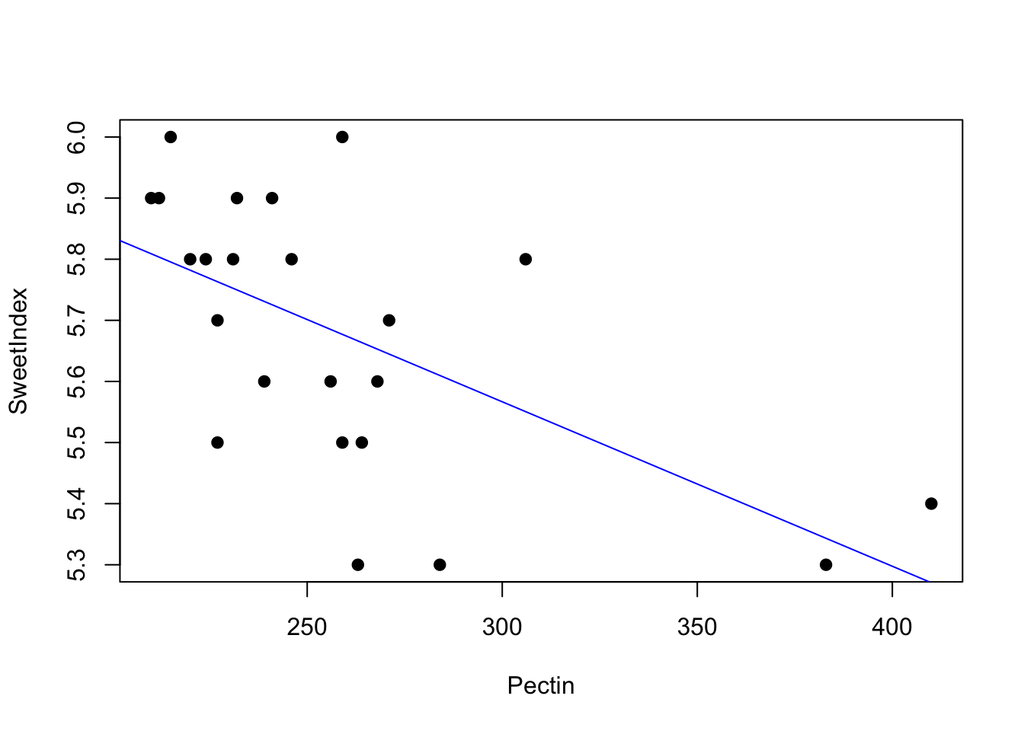

```r
sweet_minusR1= sweetnessData[-1, ]
plot(SweetIndex~Pectin,data=sweet_minusR1,pch=19)
sweetf.fit=lm(SweetIndex~Pectin,data=sweet_minusR1)
abline(sweetf.fit,col='blue')
```

#### (I)

```r
coef(sweet.fit)[2]
```

```
##       Pectin
## -0.002310626
```

```r
coef(sweetf.fit)[2]
```

```
##      Pectin
## -0.00269169
```

The slope did change as it is now -0.0026917 while with the row it was -0.002310626, so it got steeper and more negative just by a little.

#### (II)

```r
summary(sweet.fit)$r.squared
```

```
## [1] 0.2286234
```

```r
summary(sweetf.fit)$r.squared
```

```
## [1] 0.3627287
```

The $R^2$ value is 0.3627 while with the row it was 0.2286. The value increased which means that the correlation between the two variables is stronger without the row.

#### (III)

```r
summary(sweet.fit)$sigma
```

```
## [1] 0.214998
```

```r
summary(sweetf.fit)$sigma
```

```
## [1] 0.1826321
```

The sigma value did change as it decreased from 0.214 to 0.182, which means that the points are closer to the regression line.

### B

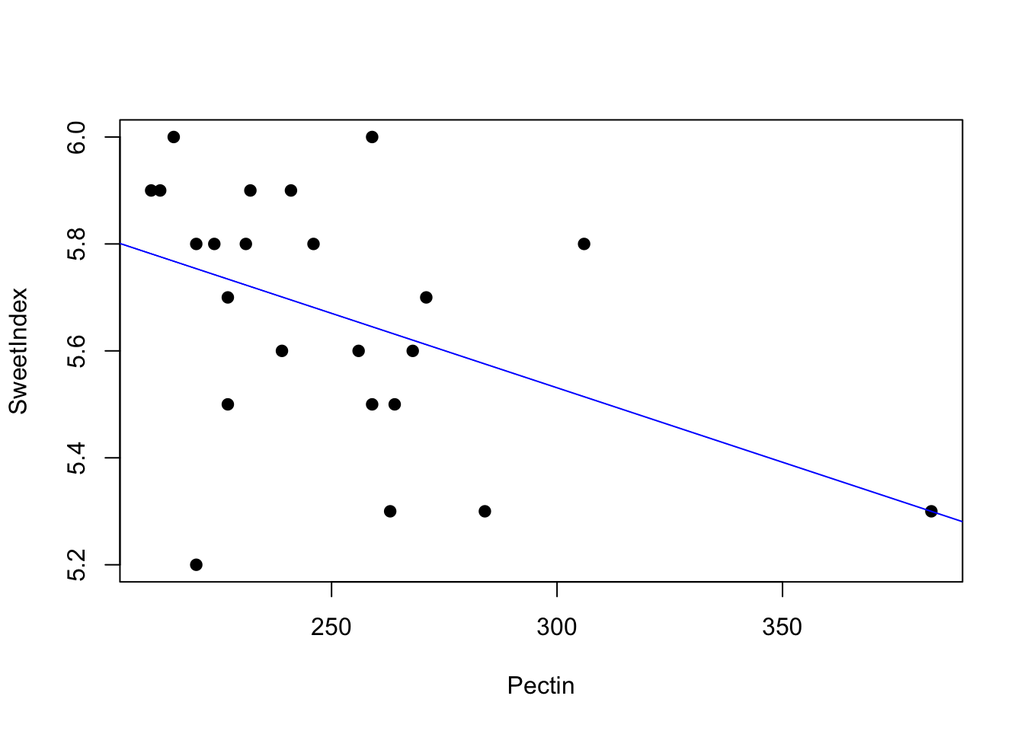

```r
sweet_minusR11= sweetnessData[-11, ]
plot(SweetIndex~Pectin,data=sweet_minusR11,pch=19)
sweetf2.fit=lm(SweetIndex~Pectin,data=sweet_minusR11)
abline(sweetf2.fit,col='blue')
```

#### (I)

```r
coef(sweet.fit)[2]
```

```
##       Pectin
## -0.002310626
```

```r
coef(sweetf2.fit)[2]
```

```
##       Pectin
## -0.002785972
```

The slope did change as it is now -0.002785872 while with the row it was -0.002310626, so it got steeper and more negative just by a little.

#### (II)

```r
summary(sweet.fit)$r.squared
```

```
## [1] 0.2286234
```

```r
summary(sweetf2.fit)$r.squared
```

```
## [1] 0.1989855
```

The $R^2$ value is 0.1989855 while with the row it was 0.2286. The value decreased which means that the correlation between the two variables is weaker without the row.

#### (III)

```r
summary(sweet.fit)$sigma
```

```
## [1] 0.214998
```

```r
summary(sweetf2.fit)$sigma
```

```
## [1] 0.2182423
```

The sigma value did change as it increased from 0.214 to 0.218, which means that the points are further from the regression line.

## Part (g)

### (i)

The p-value of the test is 14/1000 which is 0.014. This represents the probability of obtaining a sample slope as extreme as 0.0023.

### (ii)

This is a two-sided test since $\beta_1 \neq 0$ is the alternative hypothesis where there is an association between the variables. We have fairly strong evidence of a linear association between the sweetness index and the amount of pectin. (p < 0.05)

# Problem 5

## Part (a)

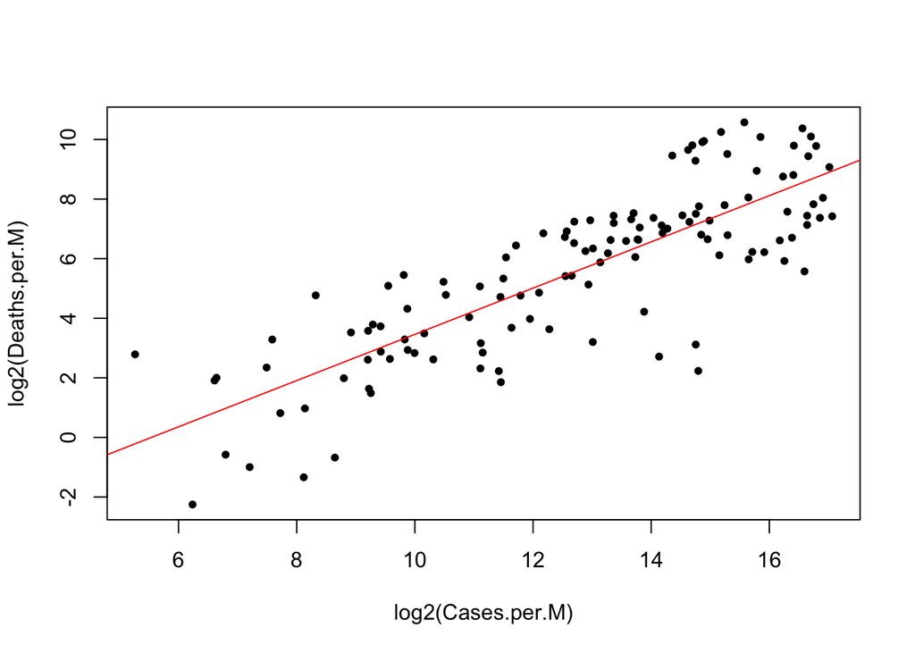

```r
COVID = read.csv("COVID.csv")

COVID$log_Deaths = log2(COVID$Deaths.per.M)
COVID$log_Cases = log2(COVID$Cases.per.M)

plot(log_Deaths ~ log_Cases, data = COVID, pch = 20, xlab = "log2(Cases.per.M)",
     ylab = "log2(Deaths.per.M)", main = "")

COVID.fit <- lm(log_Deaths ~ log_Cases, data = COVID)
abline(COVID.fit, col = "red")
```

```r
summary(COVID.fit)
```

```
##
## Call:
## lm(formula = log_Deaths ~ log_Cases, data = COVID)
##
## Residuals:
##     Min      1Q  Median      3Q     Max
## -4.9516 -1.0486  0.1863  1.0485  3.0030
##
## Coefficients:
##             Estimate Std. Error t value Pr(>|t|)
## (Intercept) -4.30090    0.64117  -6.708  6.4e-10 ***
## log_Cases    0.77621    0.04898  15.847  < 2e-16 ***
## ---
## Signif. codes:  0 '***' 0.001 '**' 0.01 '*' 0.05 '.' 0.1 ' ' 1
##
## Residual standard error: 1.61 on 123 degrees of freedom
## Multiple R-squared:  0.6712, Adjusted R-squared:  0.6686
## F-statistic: 251.1 on 1 and 123 DF,  p-value: < 2.2e-16
```

## Part (b)

```r
confint(COVID.fit, level = 0.95)
```

```
##                  2.5 %     97.5 %
## (Intercept) -5.5700475 -3.0317526
## log_Cases    0.6792557  0.8731613
```

We are 95% confident that the median increase in Deaths per million residents for every doubling of Cases per million is between $2^{0.6793}$ (1.6013) and $2^{0.8732}$ (1.8317).